# Impacto de la pandemia de COVID-19 en la autonomía económica de las mujeres

Sabrina Siniscalchi

2024-02-25

# 1 Introducción

La pandemia de COVID-19 ha dejado al descubierto y exacerbado numerosas desigualdades preexistentes en nuestras sociedades, impactando de manera desproporcionada a los grupos más vulnerables. Entre estos, las mujeres de América Latina han enfrentado retos sin precedentes que amenazan su autonomía económica, física y en la toma de decisiones. Este fenómeno no es aislado ni nuevo; refleja patrones de desigualdad de género arraigados que se agudizan en tiempos de crisis. La situación laboral de las mujeres en la región, caracterizada por una mayor precariedad e informalidad, las ha expuesto a un riesgo elevado de desempleo durante la pandemia. Además, el confinamiento, el cierre de escuelas y la necesidad de cuidar a familiares contagiados han aumentado la carga de trabajo doméstico no remunerado, una responsabilidad que recae desproporcionadamente sobre ellas, afectando sus tasas de participación en el mercado laboral en mayor medida que lo que lo hizo sobre sus pares hombres. Estas circunstancias han evidenciado cómo las emergencias sanitarias pueden profundizar las brechas de género, limitando significativamente la autonomía económica de las mujeres. La visualización que presentamos a continuación busca recoger algunos de los indicadores que ponen en evidencia el impacto de la pandemia de COVID-19 en la autonomía económica de las mujeres.

# 2 Participación en el mercado de trabajo

La pandemia de COVID-19 ha marcado un punto de inflexión en el ámbito laboral global, y América Latina no ha sido la excepción. Este evento sin precedentes ha generado un impacto significativo en las dinámicas de empleo, manifestándose en una notable disminución de las tasas de participación y ocupación laboral, así como en un incremento de la desocupación a niveles no vistos en crisis anteriores. Durante el segundo trimestre de 2020, la región se destacó desafortunadamente por registrar la mayor pérdida de horas de trabajo a nivel mundial, debido tanto a la eliminación de empleos como a la reducción de las jornadas de trabajo (OIT,2020; CEPAL,2022),. Esta situación ha repercutido de manera desproporcionada en el empleo femenino, interrumpiendo una tendencia de crecimiento sostenido de la participación de las mujeres en la fuerza laboral.

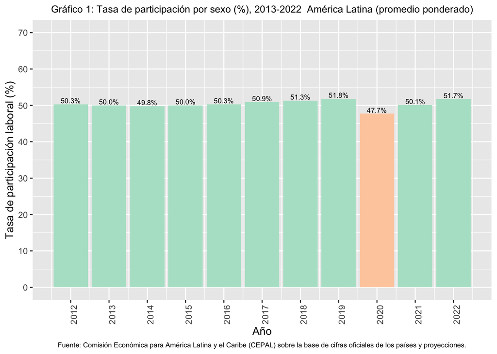

El gráfico 1 ilustra la evolución de las tasas de participación en el mercado laboral de las mujeres entre 2012 y 2022, evidenciando cómo las mujeres han sido afectadas en sus trayectorias laborales por la pandemia. No obstante ello, el panorama de la participación laboral femenina en América Latina durante y después de la pandemia de COVID-19 revela una compleja variedad de realidades nacionales, cada una con sus propias dinámicas y desafíos. La diversidad de estas situaciones queda claramente ilustrada en el Gráfico 2 que se presenta a continuación, donde se evidencia que los países con las mayores caídas en la tasa de participación de las mujeres en el mercado laboral son precisamente aquellos donde, antes de la crisis, estas tasas eran más elevadas.

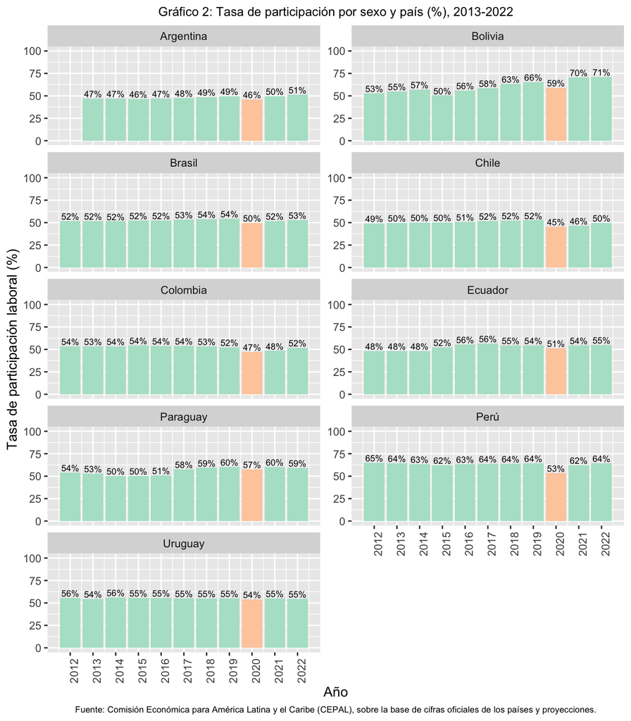

Destacan ejemplos como Perú y Bolivia, siendo particularmente notable el caso peruano, donde la tasa de participación femenina experimentó una caída del 10% durante el año 2020. Asimismo, situaciones como la de Chile reflejan un gran retroceso, regresando a niveles de participación laboral femenina que no se observaban desde hace una década.

# 3 Desempleo

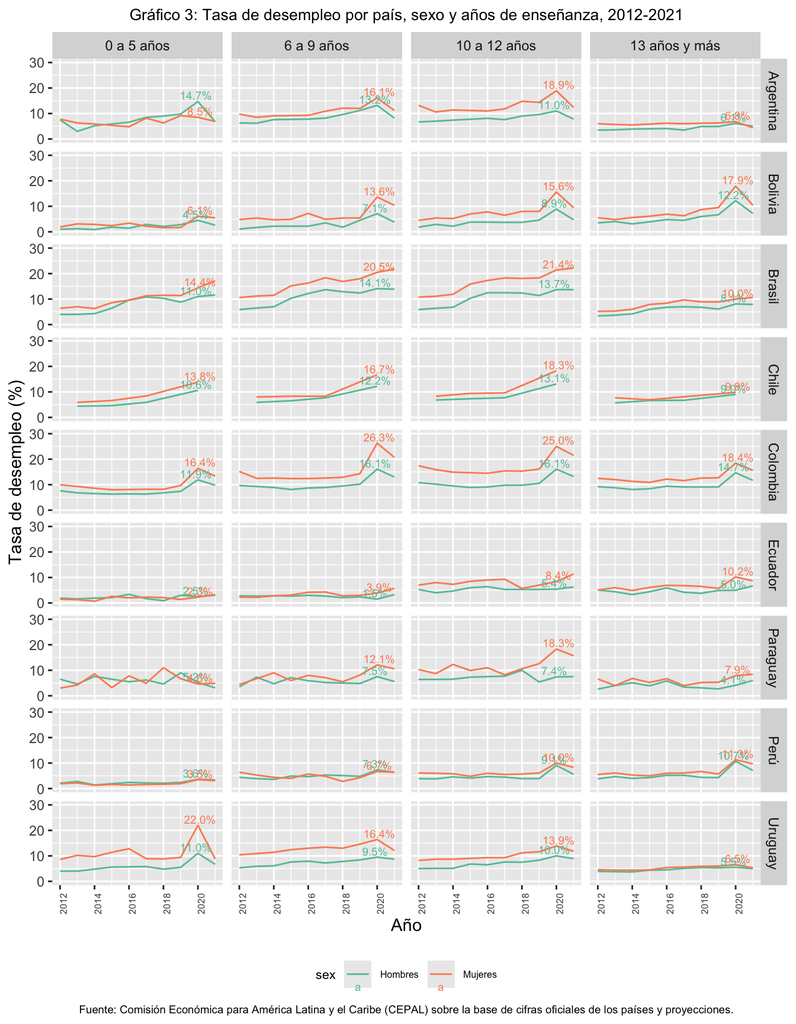

El gráfico 3 proporciona un análisis detallado de la tasa de desempleo abierto en varios países de América Latina desde 2012 hasta 2021, desglosando los datos por sexo y años de enseñanza. A lo largo de la década, se observa que las tasas de desempleo femenino generalmente superan a las de los hombres en la mayoría de los niveles educativos y países analizados. En particular, se nota una tendencia al aumento del desempleo femenino en 2020, evidenciando un impacto diferencial por género en el mercado laboral. Países como Colombia y Brasil muestran las tasas más altas de desempleo femenino, mientras que en países como Uruguay, la tasa de desempleo femenino experimenta un incremento notable durante los años de la pandemia, siendo el país donde las mujeres con menor formación sufrieron mayor incremento en la tasa de desempleo.

# 4 Pobreza

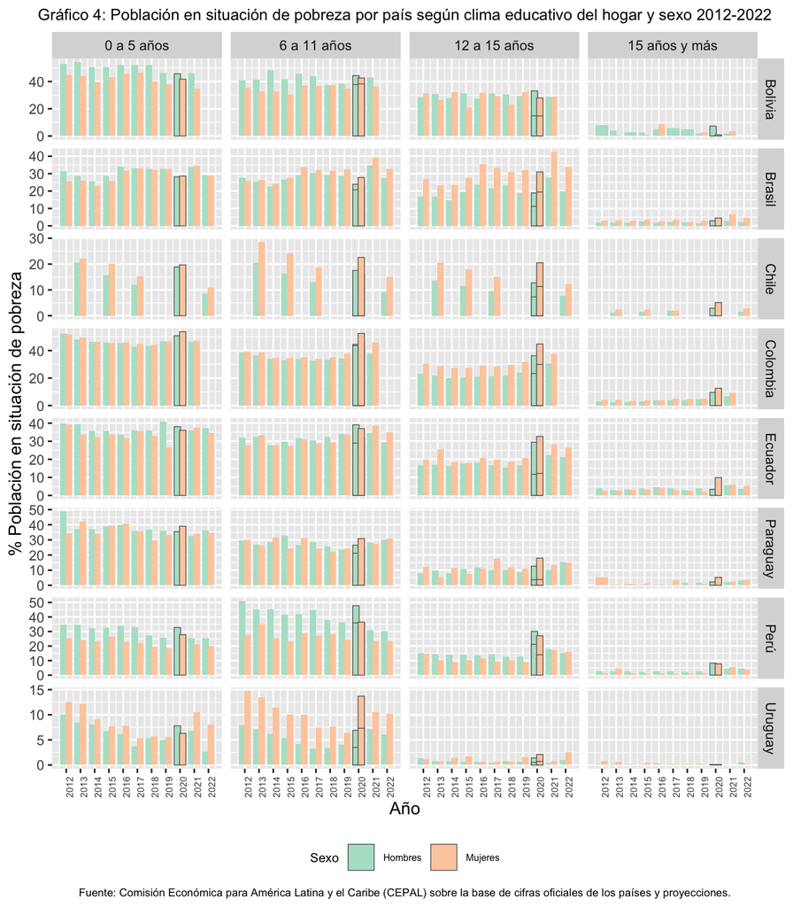

# 5 Variación de los indicadores por país

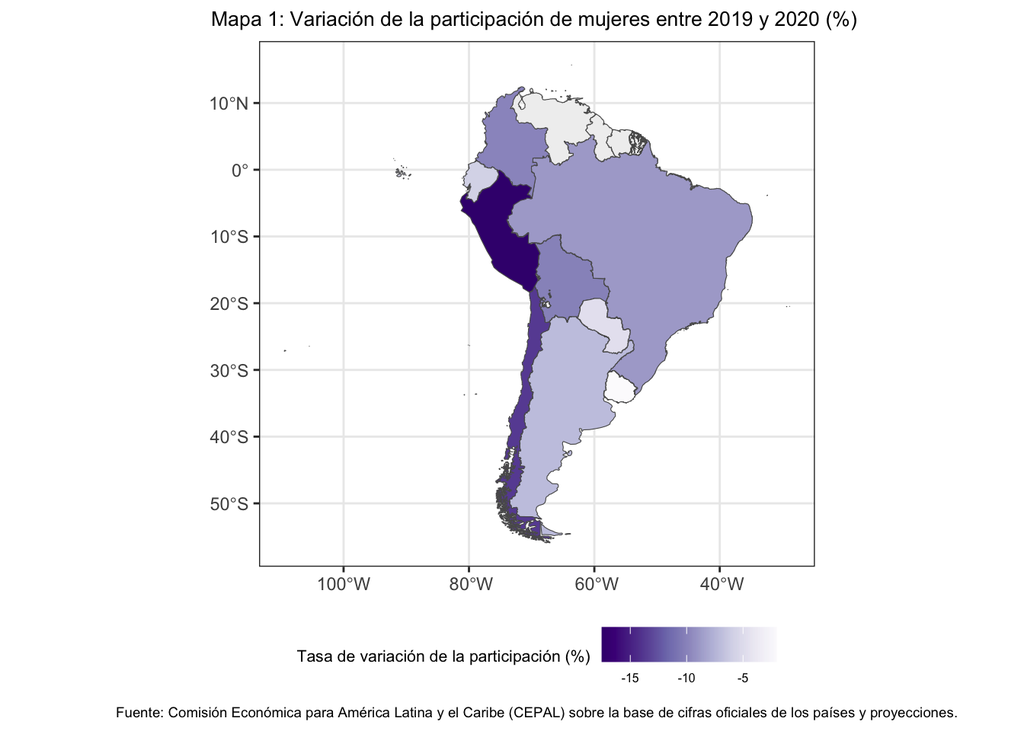

El mapa 1 muestra una disminución en la participación de las mujeres en el mercado laboral entre los años 2019 y 2020 en varios países de América Latina, destacándose especialmente en la región andina, con tas de caída de la participacíon de las mujeres en el mercado laboral de más de 10% con respecto a sus niveles de 2019.

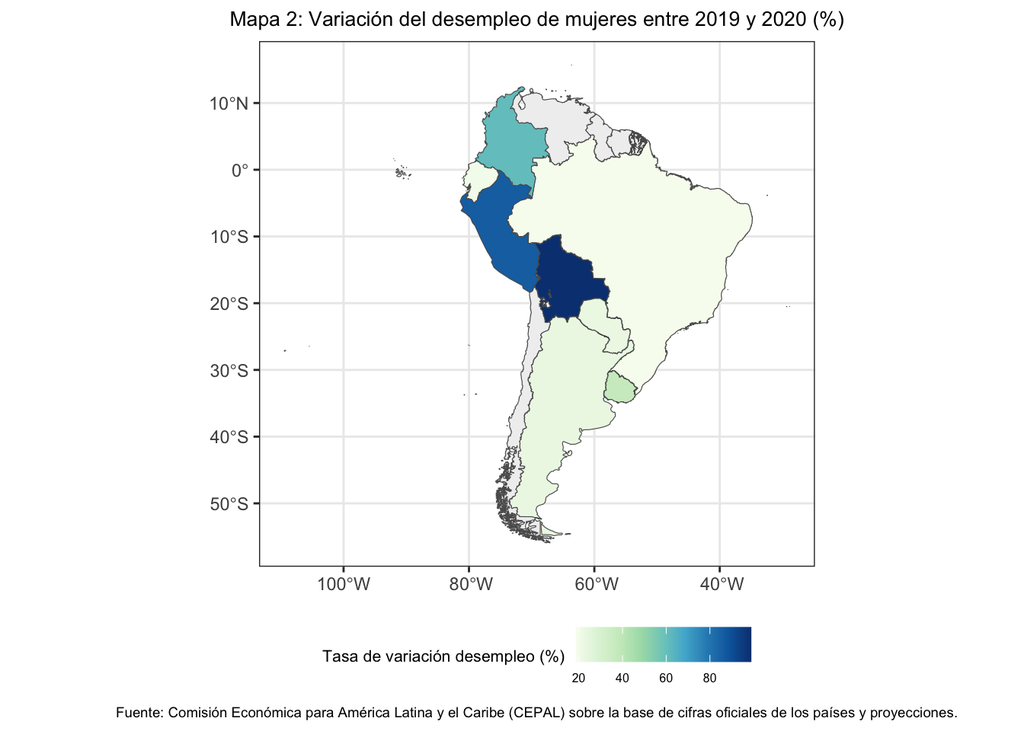

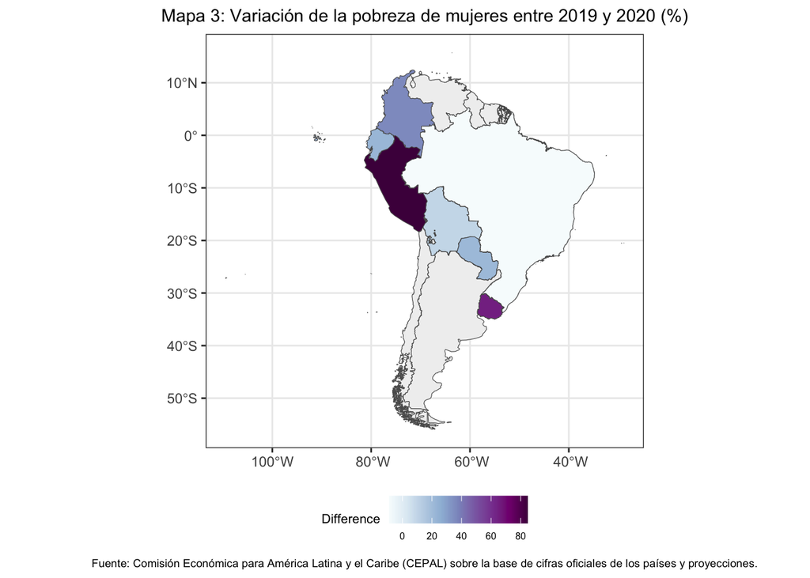